# LBB Classification 2

Francis Yeh

2 Apr 2020

# 1 Introduction

## 1.1 Background

```r
knitr::opts_chunk$set(cache=TRUE)
options(scipen = 9999)
```

The variable `default` in the dataset indicates whether the applicant did default on the loan issued by the bank.

The dataset contains  
`checking_balance` and `savings_balance`: Status of existing checking / savings account  
`credit_history`: Between critical, good, perfect, poor and very good  
`purpose`: Between business, car(new), car(used), education, furniture and renovations  
`employment_duration`: Present employment since  
`percent_of_income`: Installment rate in percentage of disposable income  
`years_at_residence`: Present residence since  
`other_credit`: Other installment plans (bank / store)  
`housing`: Between rent, own, or for free  
`job`: Between management, skilled, unskilled and unemployed  
`dependents`: Number of people being liable to provide maintenance for  
`phone`: Between none and yes (registered under customer name)

## 1.2 Data Source

The dataset consists of 1000 observations and 17 variables.

http://archive.ics.uci.edu/ml/datasets/Statlog+%28German+Credit+Data%29

### 1.2.1 Overview of Variables

1: `checking_balance` - Status of existing checking account a: < 0 DM b: 0 <= … < 200 DM c: >= 200 DM d: unknown

2: `Duration in month`

3: `credit_history` a : perfect - no credits taken/ all credits paid back duly b : very good - all credits at this bank paid back duly c : good - existing credits paid back duly till now d : poor - delay in paying off in the past e : critical - critical account/ other credits existing (not at this bank)

4: `Purpose` a: car (new) b: car (used) c: furniture/equipment d: radio/television e: domestic appliances f: repairs g: education h: (vacation - does not exist?) i: retraining j: business k: others

5: `Credit amount`

6: `savings_balance` - Savings account/bonds a: … < 100 DM b: 100 <= … < 500 DM c: 500 <= … < 1000 DM d: .. >= 1000 DM e: unknown/ no savings account

7: `employment_duration` - Present employment since a : unemployed b : … < 1 year c : 1 <= … < 4 years d : 4 <= … < 7 years e : .. >= 7 years

8: `percent_of_income` - Installment rate in percentage of disposable income

9: `Years at residence` - Present residence since

10: `Age in years`

11: `Other Credit` - Other installment plans a : bank b : stores c : none

12: `Housing` a : rent b : own c : for free

13: `Number of existing credits at this bank`

14: `Job` a : unemployed/ unskilled - non-resident b : unskilled - resident c : skilled employee / official d : management/ self-employed/highly qualified employee/ officer

15: `Dependent` - Number of people being liable to provide maintenance for

16: `Telephone` a : none b : yes, registered under the customer’s name

17: `Default` a : yes b : no

## 1.3 Libraries and Setup

### 1.3.1 Functions used to determine accuracy computation of the model

```r
accuracy <- function(data){
  correct <- 0
  for (i in c(1:nrow(data))){
    #Compare actual and predicted class
    if(data[i,1] == data[i,2]){
      correct <- correct + 1
    }
  }
  percentage <- correct/nrow(data)*100
  return(percentage)
}
```

## 1.4 Appendix (Decision Tree)

```r
loans <- read.csv("data_input/loan.csv", header=TRUE)
loans_intrain <- sample(nrow(loans), nrow(loans)*0.8)
loans_train <- loans[loans_intrain, ]
loans_test <- loans[-loans_intrain, ]
```

```r
loans_model_dt <- ctree(default ~ ., loans_train[ ,-3])
```

```r
print(loans_model_dt)
```

```
##
## Model formula:
## default ~ checking_balance + months_loan_duration + purpose +
##     amount + savings_balance + employment_duration + percent_of_income +
##     years_at_residence + age + other_credit + housing + existing_loans_count +
##     job + dependents + phone
##
## Fitted party:
## [1] root
## |   [2] checking_balance < 0 DM, 1 - 200 DM
## |   |   [3] months_loan_duration <= 21: no (n = 257, err = 35.8%)
## |   |   [4] months_loan_duration > 21: yes (n = 196, err = 43.4%)
## |   [5] checking_balance > 200 DM, unknown
## |   |   [6] other_credit in bank, store: no (n = 60, err = 26.7%)
## |   |   [7] other_credit in none
## |   |   |   [8] checking_balance > 200 DM: no (n = 35, err = 28.6%)
## |   |   |   [9] checking_balance in unknown: no (n = 252, err = 7.5%)
##
## Number of inner nodes:    4
## Number of terminal nodes: 5
```

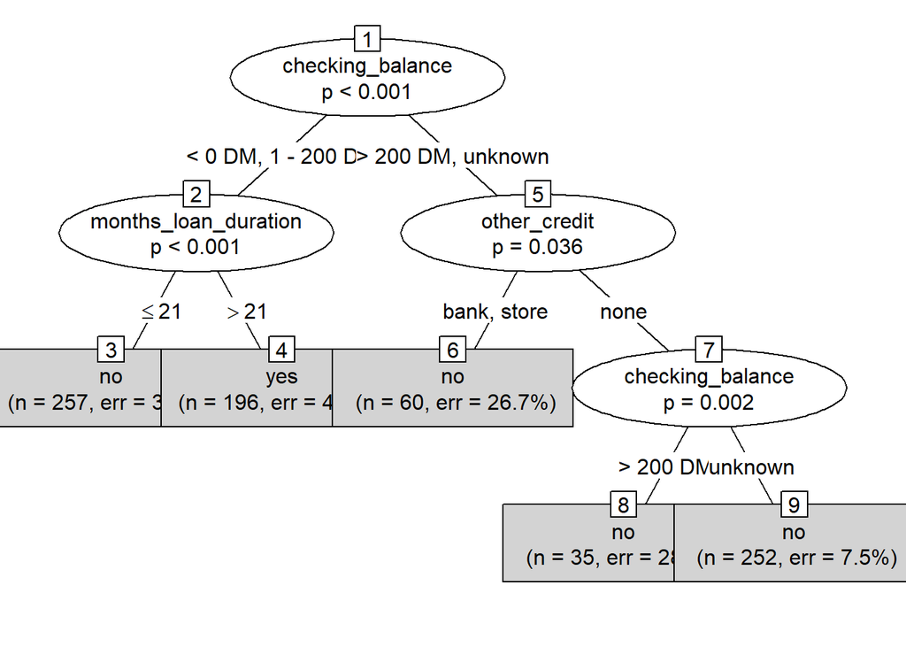

```r
plot(loans_model_dt, type="simple")
```

```r
loans_pred_dt <- predict(loans_model_dt, loans_test)
```

```r
summary(loans_pred_dt)
```

```
##  no yes
## 159  41
```

### 1.4.1 Confusion Matrix

```r
confusionMatrix(loans_pred_dt, loans_test$default, positive = "yes")
```

```
## Confusion Matrix and Statistics
##
##           Reference
## Prediction  no yes
##        no  130  29
##        yes  18  23
##
##                Accuracy : 0.765
##                  95% CI : (0.7, 0.8219)
##     No Information Rate : 0.74
##     P-Value [Acc > NIR] : 0.2360
##
##                   Kappa : 0.3443
##
##  Mcnemar's Test P-Value : 0.1447
##
##             Sensitivity : 0.4423
##             Specificity : 0.8784
##          Pos Pred Value : 0.5610
##          Neg Pred Value : 0.8176
##              Prevalence : 0.2600
##          Detection Rate : 0.1150
##    Detection Prevalence : 0.2050
##       Balanced Accuracy : 0.6603
##
##        'Positive' Class : yes
##
```

# 2 Preprocessing

## 2.1 Data Table

```r
# Read the dataset

loans <- read.csv("data_input/loan.csv", header=TRUE)
str(loans)
```

```
## 'data.frame':    1000 obs. of  17 variables:
##  $ checking_balance    : Factor w/ 4 levels "< 0 DM","> 200 DM",..: 1 3 4 1 1 4 4 3 4 3 ...
##  $ months_loan_duration: int  6 48 12 42 24 36 24 36 12 30 ...
##  $ credit_history      : Factor w/ 5 levels "critical","good",..: 1 2 1 2 4 2 2 2 2 1 ...
##  $ purpose             : Factor w/ 6 levels "business","car",..: 5 5 4 5 2 4 5 2 5 2 ...
##  $ amount              : int  1169 5951 2096 7882 4870 9055 2835 6948 3059 5234 ...
##  $ savings_balance     : Factor w/ 5 levels "< 100 DM","> 1000 DM",..: 5 1 1 1 1 5 4 1 2 1 ...
##  $ employment_duration : Factor w/ 5 levels "< 1 year","> 7 years",..: 2 3 4 4 3 3 2 3 4 5 ...
##  $ percent_of_income   : int  4 2 2 2 3 2 3 2 2 4 ...
##  $ years_at_residence  : int  4 2 3 4 4 4 4 2 4 2 ...
##  $ age                 : int  67 22 49 45 53 35 53 35 61 28 ...
##  $ other_credit        : Factor w/ 3 levels "bank","none",..: 2 2 2 2 2 2 2 2 2 2 ...
##  $ housing             : Factor w/ 3 levels "other","own",..: 2 2 2 1 1 1 2 3 2 2 ...
##  $ existing_loans_count: int  2 1 1 1 2 1 1 1 1 2 ...
##  $ job                 : Factor w/ 4 levels "management","skilled",..: 2 2 4 2 2 4 2 1 4 1 ...
##  $ dependents          : int  1 1 2 2 2 2 1 1 1 1 ...
##  $ phone               : Factor w/ 2 levels "no","yes": 2 1 1 1 1 2 1 2 1 1 ...
##  $ default             : Factor w/ 2 levels "no","yes": 1 2 1 1 2 1 1 1 1 2 ...
```

## 2.2 Checking missing values

There is no missing values in the variables

```r
describe(loans)
```

```
## loans
##
##  17  Variables      1000  Observations
## --------------------------------------------------------------------------------
## checking_balance
##        n  missing distinct
##     1000        0        4
##
## Value          < 0 DM   > 200 DM 1 - 200 DM    unknown
## Frequency         274         63        269        394
## Proportion      0.274      0.063      0.269      0.394
## --------------------------------------------------------------------------------
## months_loan_duration
##        n  missing distinct     Info     Mean      Gmd      .05      .10
##     1000        0       33    0.985     20.9    12.98        6        9
##      .25      .50      .75      .90      .95
##       12       18       24       36       48
##
## lowest :  4  5  6  7  8, highest: 47 48 54 60 72
## --------------------------------------------------------------------------------
## credit_history
##        n  missing distinct
##     1000        0        5
##
## lowest : critical  good      perfect   poor      very good
## highest: critical  good      perfect   poor      very good
##
## Value       critical      good   perfect      poor very good
## Frequency        293       530        40        88        49
## Proportion     0.293     0.530     0.040     0.088     0.049
## --------------------------------------------------------------------------------
## purpose
##        n  missing distinct
##     1000        0        6
##
## lowest : business             car                  car0                 education            furniture/appliances
## highest: car                  car0                 education            furniture/appliances renovations
##
## Value                  business                  car                 car0
## Frequency                    97                  337                   12
```

[output cut: 105 more lines]

```
##        n  missing distinct
##     1000        0        2
##
## Value         no   yes
## Frequency    596   404
## Proportion 0.596 0.404
## --------------------------------------------------------------------------------
## default
##        n  missing distinct
##     1000        0        2
##
## Value       no yes
## Frequency  700 300
## Proportion 0.7 0.3
## --------------------------------------------------------------------------------
```

```r
any(is.na(loans))
```

```
## [1] FALSE
```

## 2.3 Breakdown to age bracket

```r
library(dplyr)

loans <- loans %>% mutate(agegroup = case_when(
                                             age >= 54 ~ '5',
                                             age >= 44  & age < 54 ~ '4',
                                             age >= 34  & age < 44 ~ '3',
                                             age >= 24  & age < 34 ~ '2',
                                             age >= 16  & age < 24 ~ '1'))
```

# 3 Exploratory Data Analysis

## 3.1 Summary of loan amounts

```r
summary(loans$amount)
```

```
##    Min. 1st Qu.  Median    Mean 3rd Qu.    Max.
##     250    1366    2320    3271    3972   18424
```

A majority of loans (75%) have amount less than 4000 DM.

## 3.2 Breakdown of Loans by Age Group

```r
round(prop.table(table(loans$agegroup)) * 100, 2)
```

```
##
##    1    2    3    4    5
## 10.5 41.1 26.6 12.9  8.9
```

## 3.3 Breakdown of Loans by Purpose

```r
round(prop.table(table(loans$purpose)) * 100, 2)
```

```
##
##             business                  car                 car0
##                  9.7                 33.7                  1.2
##            education furniture/appliances          renovations
##                  5.9                 47.3                  2.2
```

The table shows percentages breakdown of loans business by purpose. For vehicle loans, it is made up of car(33.7%) and car0(1.2%) customers. A low 2.2% for renovation loan.

## 3.4 Breakdown of Loans(Default vs Paid)

```r
round(prop.table(table(loans$default)) * 100, 2)
```

```
##
##  no yes
##  70  30
```

## 3.5 Breakdown of Loans by Credit History

```r
round(prop.table(table(loans$credit_history)) * 100, 2)
```

```
##
##  critical      good   perfect      poor very good
##      29.3      53.0       4.0       8.8       4.9
```

## 3.6 Defaulted Loans according to agegroup

```r
loans$agegroup <- factor(loans$agegroup,
                                levels = c("1","2","3","4","5"))
summary(loans[loans$default == "yes", "agegroup"])
```

```
##   1   2   3   4   5
##  42 139  64  31  24
```

About 60% of the “default” borrowers are of age 34 years or younger.

## 3.7 Paid Loans according to agegroup

```r
loans$agegroup <- factor(loans$agegroup,
                                levels = c("1","2","3","4","5"))
summary(loans[loans$default == "no", "agegroup"])
```

```
##   1   2   3   4   5
##  63 272 202  98  65
```

A relatively high proportion of borrowers(40%)in the agegroup (less than 24 years) default their loans

## 3.8 Defaulted Loans according to checking_balance

```r
loans$checking_balance <- factor(loans$checking_balance,
                                levels = c("< 0 DM",
                                           "1 - 200 DM",
                                           "> 200 DM",
                                           "unknown"))
summary(loans[loans$default == "yes", "checking_balance"])
```

```
##     < 0 DM 1 - 200 DM   > 200 DM    unknown
##        135        105         14         46
```

Focus on those with checking balance less than 200 DM (80%) defaulted the loans

## 3.9 Paid Loans according to checking_balance

```r
summary(loans[loans$default == "no", "checking_balance"])
```

```
##     < 0 DM 1 - 200 DM   > 200 DM    unknown
##        139        164         49        348
```

303 out of 700 (43.2%) borrowers with checking balance less than 200DM paid their loans.

## 3.10 Defaulted Loans according to savings_balance

```r
loans$savings_balance <- factor(loans$savings_balance,
                                levels = c("< 100 DM",
                                           "100 - 500 DM",
                                           "500 - 1000 DM",
                                           "> 1000 DM",
                                           "unknown"))
summary(loans[loans$default == "yes", "savings_balance"])
```

```
##      < 100 DM  100 - 500 DM 500 - 1000 DM     > 1000 DM       unknown
##           217            34            11             6            32
```

Focus on savings_balance <100 DM 217 /300 (72.3%) 217+34+11+6+32

## 3.11 Paid Loans according to savings_balance

```r
summary(loans[loans$default == "no", "savings_balance"])
```

```
##      < 100 DM  100 - 500 DM 500 - 1000 DM     > 1000 DM       unknown
##           386            69            52            42           151
```

## 3.12 Defaulted loans according to credit_history

```r
loans$credit_history <- factor(loans$credit_history,
                                levels = c("critical",
                                           "poor",
                                           "good",
                                           "very good",
                                           "perfect"))
summary(loans[loans$default == "yes", "credit_history"])
```

```
##  critical      poor      good very good   perfect
##        50        28       169        28        25
```

Surprisingly, borrowers with credit_history with good, very good and perfect rating have defaulted their loans. Need to understand further if there are some issues on how we classify the customer into good, very good and perfect grouping and how these loans were structured

## 3.13 Paid loans according to credit_history

```r
summary(loans[loans$default == "no", "credit_history"])
```

```
##  critical      poor      good very good   perfect
##       243        60       361        21        15
```

A sizable no (243) of 700 borrowers(with “critical” credit history) and 60 out of 700 borrowers (with “poor” credit history) have paid their loans.

## 3.14 Defaulted loans according to other_credit

```r
loans$other_credit <- factor(loans$other_credit,
                                levels = c("none",
                                           "store",
                                           "bank"))
summary(loans[loans$default == "yes", "other_credit"])
```

```
##  none store  bank
##   224    19    57
```

A sizeable no (224) of borrowers defaulted their loan repayment when they have none “Other Credit”

## 3.15 Paid loans according to other_credit

```r
summary(loans[loans$default == "no", "other_credit"])
```

```
##  none store  bank
##   590    28    82
```

# 4 Split the data to Train and Test

```r
loans_intrain <- sample(nrow(loans), nrow(loans)*0.8)
loans_train <- loans[loans_intrain, ]
loans_test <- loans[-loans_intrain, ]

loans_train_labels = loans[loans_intrain,17]
loans_test_labels = loans[-loans_intrain,17]
```

## 4.1 Checking the classes are equally represented in train and test sets

The table shows “default” percentages for train (30.25%) and test (29%) customers in the train data.

```r
prop.table(table(loans_train$default))
```

```
##
##     no    yes
## 0.6975 0.3025
```

```r
prop.table(table(loans_test$default))
```

```
##
##   no  yes
## 0.71 0.29
```

Both Train and Test sets are proportionally distributed in term of default.

# 5 Creating our Random Forest

```r
set.seed(10)
library(randomForest)
loans_rf <- randomForest(default ~., data=loans_train, mtry=8, ntree=1500, importance=TRUE)
```

```r
loans_rf
```

```
##
## Call:
##  randomForest(formula = default ~ ., data = loans_train, mtry = 8,      ntree = 1500, importance = TRUE)
##                Type of random forest: classification
##                      Number of trees: 1500
## No. of variables tried at each split: 8
##
##         OOB estimate of  error rate: 25.5%
## Confusion matrix:
##      no yes class.error
## no  497  61   0.1093190
## yes 143  99   0.5909091
```

## 5.1 Confusion Matrix

```r
loansrf_pred_dt = predict(loans_rf, loans_test)
summary(loansrf_pred_dt)
```

```
##  no yes
## 156  44
```

```r
confusionMatrix(loansrf_pred_dt, loans_test_labels, positive="yes")
```

```
## Confusion Matrix and Statistics
##
##           Reference
## Prediction  no yes
##        no  128  28
##        yes  14  30
##
##                Accuracy : 0.79
##                  95% CI : (0.7269, 0.8443)
##     No Information Rate : 0.71
##     P-Value [Acc > NIR] : 0.00660
##
##                   Kappa : 0.4508
##
##  Mcnemar's Test P-Value : 0.04486
##
##             Sensitivity : 0.5172
##             Specificity : 0.9014
##          Pos Pred Value : 0.6818
##          Neg Pred Value : 0.8205
##              Prevalence : 0.2900
##          Detection Rate : 0.1500
##    Detection Prevalence : 0.2200
##       Balanced Accuracy : 0.7093
##
##        'Positive' Class : yes
##
```

```r
sum(loansrf_pred_dt==loans_test_labels) / nrow(loans_test)
```

```
## [1] 0.79
```

## 5.2 Variable Importance

```r
varImp(loans_rf)
```

```
##                             no       yes
## checking_balance     41.273055 41.273055
## months_loan_duration 23.317524 23.317524
## credit_history       16.718340 16.718340
## purpose               7.256822  7.256822
## amount               13.820210 13.820210
## savings_balance      10.945574 10.945574
## employment_duration   7.696846  7.696846
## percent_of_income     4.120584  4.120584
## years_at_residence    4.801670  4.801670
## age                   9.977483  9.977483
## other_credit          8.593560  8.593560
## housing               4.823531  4.823531
## existing_loans_count  3.498945  3.498945
## job                   2.134505  2.134505
## dependents            3.601459  3.601459
## phone                 3.215357  3.215357
## agegroup              5.243484  5.243484
```

## 5.3 Variable Importance Plot

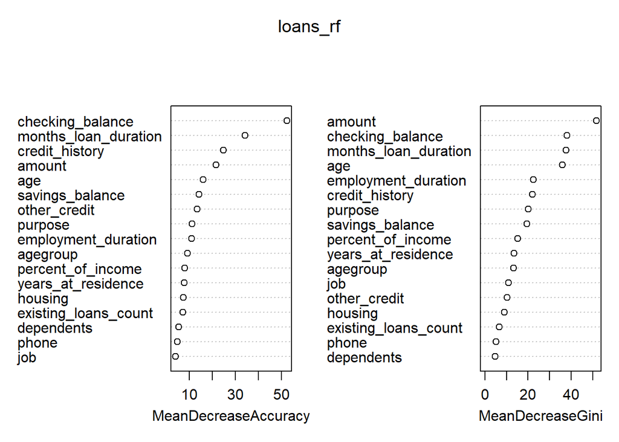

```r
varImpPlot(loans_rf)
```

By removing some of the columns with low importance, the accuracy could be improved.

```r
imp <- importance(loans_rf)
impvar <- imp[order(imp[ ,3],decreasing = TRUE),]
impvar
```

```
##                             no        yes MeanDecreaseAccuracy MeanDecreaseGini
## checking_balance     28.951983 53.5941262            52.575860        38.067942
## months_loan_duration 29.544060 17.0909869            34.340529        37.686368
## credit_history       22.178209 11.2584708            24.830891        21.978308
## amount               19.359243  8.2811766            21.591595        51.873225
## age                  16.278782  3.6761832            16.043923        36.028236
## savings_balance       3.198841 18.6923081            14.233831        19.589923
## other_credit         13.349486  3.8376339            13.491297        10.327407
## purpose              12.731994  1.7816508            11.262278        20.187652
## employment_duration   9.312251  6.0814416            11.069282        22.496597
## agegroup             11.807724 -1.3207551             9.143621        13.386819
## percent_of_income    12.828614 -4.5874450             7.964224        15.327043
## years_at_residence   10.219292 -0.6159524             7.900121        13.580280
## housing               8.151349  1.4957121             7.375720         8.964400
## existing_loans_count  9.101789 -2.1039003             7.147970         6.571022
## dependents            4.396462  2.8064570             5.416187         4.750856
## phone                 4.453613  1.9771016             4.898063         5.106403
## job                   6.921611 -2.6526019             3.990288        10.968604
```

# 6 Creating our Random Forest (using Caret)

```r
library(caret)
trCtrl <- trainControl(method = "repeatedcv",
                          number = 10,
                          repeats =3,
                          savePredictions = "final",
                          classProbs = T,)
set.seed(10)
loans_forest <- train(default~.,
             data = loans,
             method = "rf",
             trControl = trCtrl)
```

```r
loans_forest
```

```
## Random Forest
##
## 1000 samples
##   17 predictor
##    2 classes: 'no', 'yes'
##
## No pre-processing
## Resampling: Cross-Validated (10 fold, repeated 3 times)
## Summary of sample sizes: 900, 900, 900, 900, 900, 900, ...
## Resampling results across tuning parameters:
##
##   mtry  Accuracy   Kappa
##    2    0.7223333  0.1072819
##   20    0.7590000  0.3731617
##   39    0.7570000  0.3780389
##
## Accuracy was used to select the optimal model using the largest value.
## The final value used for the model was mtry = 20.
```

As shown, with the use of caret package, this provides the “suggestion” to improve the Accuracy of the model by the use of tuning parameter ie. mtry

```r
loans_forest$finalModel
```

```
##
## Call:
##  randomForest(x = x, y = y, mtry = param$mtry)
##                Type of random forest: classification
##                      Number of trees: 500
## No. of variables tried at each split: 20
##
##         OOB estimate of  error rate: 23.8%
## Confusion matrix:
##      no yes class.error
## no  624  76   0.1085714
## yes 162 138   0.5400000
```

## 6.1 Random Forest (Caret) with tuning

```r
tunegrid <- expand.grid(.mtry = (1:20))
```

```r
trCtrl <- trainControl(method = "repeatedcv",
                          number = 10,
                          repeats =3,
                          savePredictions = "final",
                          classProbs = T,
                          search='grid')
set.seed(10)
loans_forest1 <- train(default~.,
             data = loans,
             method = "rf",
             metric = "Accuracy",
             tuneGrid=tunegrid,
             ntree=1500,
             trControl = trCtrl)
```

As shown, with the manual adjustment of tuning parameter ie. ntree at 1500, this does not necessarily improve the performance of the model.

```r
saveRDS(loans_forest1, file = "loans_forest1.RDS")
```

```r
print(loans_forest1)
```

```
## Random Forest
##
## 1000 samples
##   17 predictor
##    2 classes: 'no', 'yes'
##
## No pre-processing
## Resampling: Cross-Validated (10 fold, repeated 3 times)
## Summary of sample sizes: 900, 900, 900, 900, 900, 900, ...
## Resampling results across tuning parameters:
##
##   mtry  Accuracy   Kappa
##    1    0.7000000  0.0000000
##    2    0.7216667  0.1031552
##    3    0.7430000  0.2357679
##    4    0.7506667  0.2822056
##    5    0.7520000  0.3035790
##    6    0.7490000  0.3046150
##    7    0.7520000  0.3228678
##    8    0.7506667  0.3244750
##    9    0.7570000  0.3445573
##   10    0.7586667  0.3554566
##   11    0.7596667  0.3610346
##   12    0.7580000  0.3573765
##   13    0.7593333  0.3628039
##   14    0.7613333  0.3710725
##   15    0.7623333  0.3757653
##   16    0.7620000  0.3753514
##   17    0.7610000  0.3737687
##   18    0.7623333  0.3775485
##   19    0.7583333  0.3717011
##   20    0.7586667  0.3721479
##
## Accuracy was used to select the optimal model using the largest value.
## The final value used for the model was mtry = 15.
```

## 6.2 Confusion Matrix

```r
loans_forest1$finalModel
```

```
##
## Call:
##  randomForest(x = x, y = y, ntree = 1500, mtry = param$mtry)
##                Type of random forest: classification
##                      Number of trees: 1500
## No. of variables tried at each split: 15
##
##         OOB estimate of  error rate: 24%
## Confusion matrix:
##      no yes class.error
## no  625  75   0.1071429
## yes 165 135   0.5500000
```

```r
varImp(loans_forest1)
```

```
## rf variable importance
##
##   only 20 most important variables shown (out of 39)
##
##                                Overall
## amount                         100.000
## age                             64.421
## months_loan_duration            64.302
## checking_balanceunknown         53.973
## percent_of_income               24.288
## years_at_residence              23.935
## savings_balanceunknown          12.852
## other_creditbank                11.190
## existing_loans_count            11.074
## phoneyes                        10.303
## purposecar                       9.845
## credit_historyvery good          9.714
## purposefurniture/appliances      9.359
## housingown                       9.135
## employment_duration1 - 4 years   8.808
## checking_balance1 - 200 DM       8.775
## credit_historygood               8.459
## credit_historyperfect            8.431
## jobskilled                       8.155
## employment_duration> 7 years     7.444
```

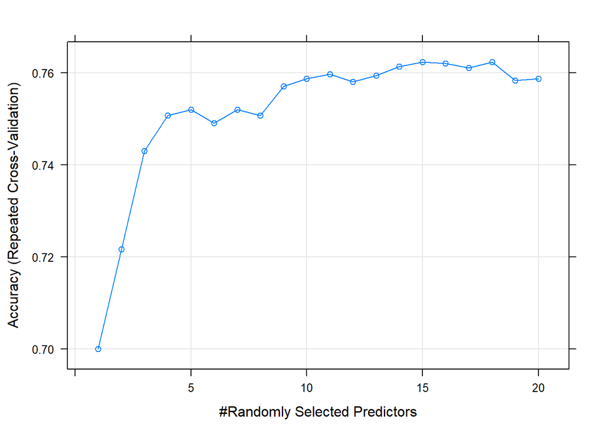

```r
plot(loans_forest1)
```

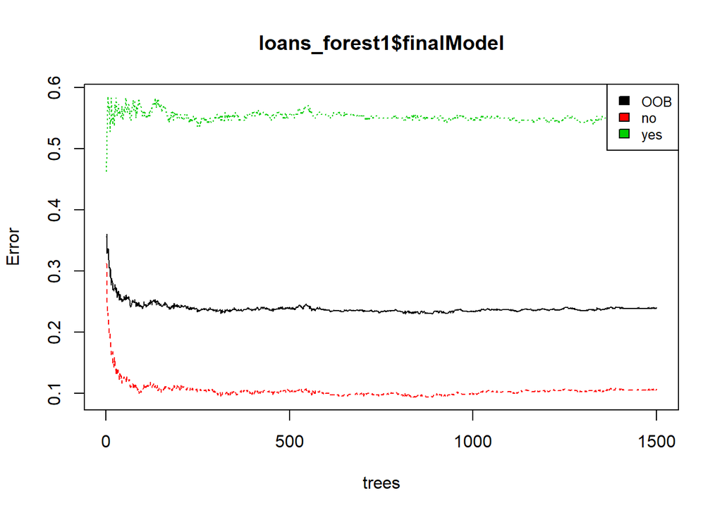

```r
plot(loans_forest1$finalModel)
legend("topright", colnames(loans_forest1$finalModel$err.rate), col=1:6, cex=0.8,fill=1:6)
```

# 7 Summary

As illustrated above, a model improvement for the random forest can be achieved by adjusting the values of tuning parameters such as ntree and mtry arguments. Generating a larger random forest by changing the ntree from 500 to 1500 may not necessarily improve the performance of the model.

Sensitivity is the percentage of true records that one predicted correctly. Specificity, on the other hand, is to measure what portion of the actual false records one predicted correctly. With additional use of cross validation, the random forest using caret package seems to perform better in term of Sensitivity.

Below please find the side by side (snapshot)comparison of the approaches.

```r
dd %>%
  kable() %>%
  kable_styling()
```

| x |
| --- |
| Desc |
| Accuracy |
| Precision |
| Neg Pred |
| Sensitivity |
| Specificity |
| OOB Error |

[output not shown]

[output not shown]

[output not shown]

| x |
| --- |
| Decision_Tree |
| 76.5% |
| 56.1% |
| 81.76% |
| 44.23% |
| 87.84% |
| 23.5% |